# GCCR Factor Influence

# Junk Bonds: Number of Companies in the Universe

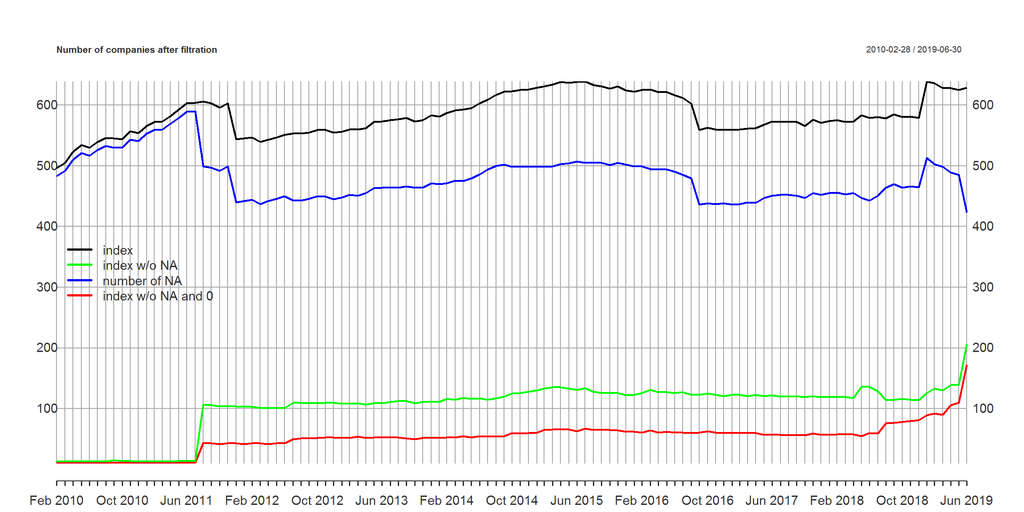

# Junk Bonds: Number of Companies in the Universe. Summary

- We can see that for junk bonds SustFilter has around 90% of NA.
- No “decrease” pattern in NA.
- around 50% are filtered among those which have SustFilter data. In the end the percentage goes to around 10%.

# Junk Bonds: Ratios

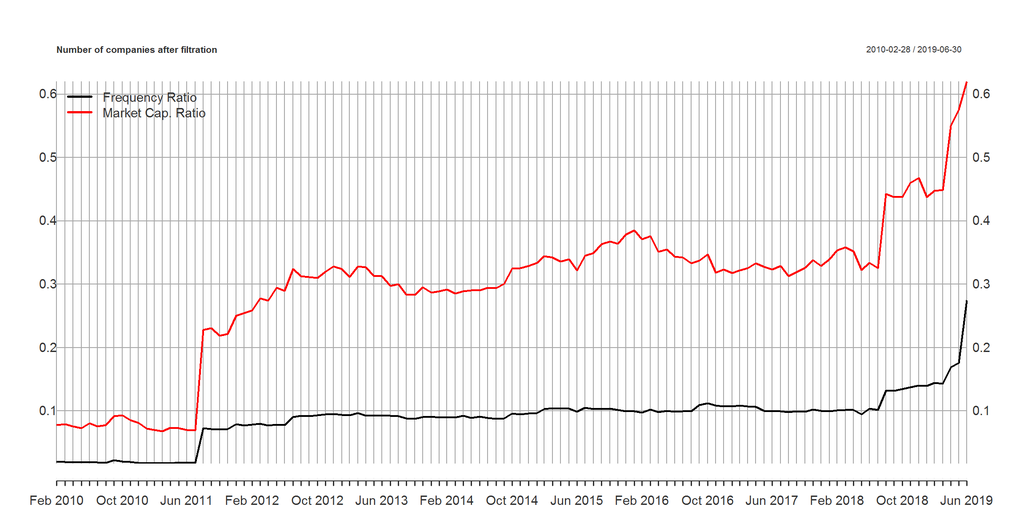

# Junk Bonds: Ratios

- Surprisingly this small amount of companies covers in the end more than 60% of the market, however, before the percentage was still around 35%.

# Investment Grade Bonds: Number of Companies in the Universe

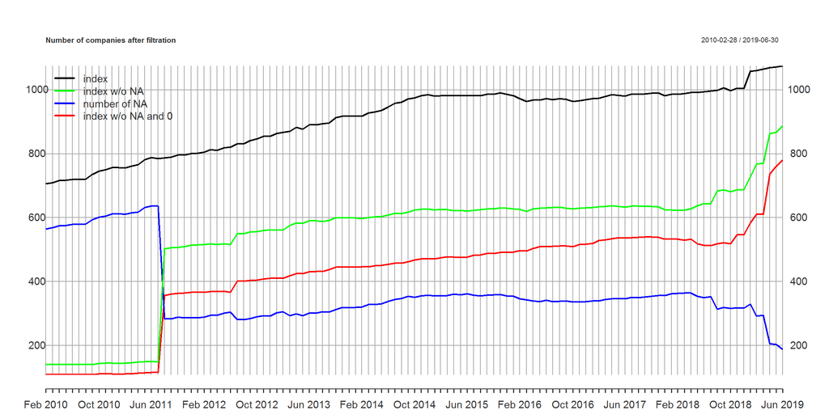